# AED Proyecto final

Cuál es la canción que pega

Gustavo A. Noriega C., Rubén Rico R., Jairo V. Tamayo R

2023-05-10

**Proyecto final**

**Análisis estadístico de datos**

**Nombre Proyecto:**¿Cuál es la canción que pega?

**Tabla de Contenido**

- Introducción
- Objetivos
- 1. Descripción de la pregunta de investigación
- 2. Descripción de los datos
- 3. Presentación del análisis estadístico de los datos
- 3.1 Modelo de Regresión Lineal Múltiple.
- 3.2 Modelo PCA.
- 3.3 Análisis de Cluster.
- Conclusiones.

## Introducción

La creación de una canción exitosa es una meta anhelada por la mayoría de los artistas, pero no siempre es fácil lograrla. En este trabajo, se propone realizar un análisis estadístico de las variables obtenidas de las dos plataformas más populares de difusión musical en línea, Spotify y YouTube, con el objetivo de identificar los atributos que influyen en la aceptación del público y el éxito comercial de una nueva canción en el mercado digital. Este estudio permitirá a los artistas enfocarse en los atributos más relevantes y optimizar así su producción, incrementando sus posibilidades de triunfar en la industria musical. Además, se pretende evaluar si es posible predecir la aceptación del público y determinar si el artista ofrece al mercado un producto apetecido.

## Objetivos

1. Establecer cuáles son las variables que afectan favorablemente la aceptación del público mediante la aplicación de métodos estadísticos al conjunto de datos de las 10 mejores canciones de múltiples artistas publicadas en Spotify.
2. Evaluar si existe alguna correlación entre el número de vistas en Youtube, el número de comentarios y el número de “me gusta”, y la frecuencia con la que es sugerido un tema por parte del algoritmo de la aplicación.
3. El objetivo principal de este proyecto es producir una aplicación de los métodos estadísticos multivariantes vistos a lo largo del curso utilizando uno o varios conjuntos de datos.

## 1. Descripción de la pregunta de investigación

El propósito de esta investigación es realizar un análisis estadístico de las variables obtenidas de dos populares plataformas de streaming de música en línea, Spotify y YouTube, para investigar los factores que influyen en la aceptación de la audiencia y el éxito comercial de nuevas canciones en el mercado digital. La pregunta principal de la investigación es: ¿Cuáles son los atributos clave que contribuyen significativamente a la aceptación por parte de la audiencia y al éxito comercial de las canciones en las plataformas digitales de música?

Los problemas de investigación identificados son los siguientes:

1. Identificar los atributos musicales y no musicales que están asociados con una mayor aceptación “likes” de la audiencia en Spotify y YouTube.
2. Determinar si existen diferencias significativas en los atributos preferidos por la audiencia entre ambas plataformas.
3. Evaluar la viabilidad de predecir la aceptación “likes” de la audiencia en función de los atributos identificados.
4. Investigar si ofrecer productos musicales con los atributos deseados influye en el éxito comercial de los artistas en la industria musical.

Al realizar un análisis estadístico de los datos obtenidos de Spotify y YouTube, esta investigación pretende proporcionar información valiosa a los artistas y productores, permitiéndoles centrarse en los atributos más relevantes y optimizar la producción de sus canciones, aumentando así sus posibilidades de éxito en la competitiva industria musical. Además, las conclusiones de este estudio pueden tener implicaciones prácticas para la toma de decisiones estratégicas en el ámbito de la promoción y distribución de música en línea.

## 2. Descripción de los datos

En el conjunto de datos ubicado en la URL https://www.kaggle.com/datasets/salvatorerastelli/spotify-and-youtube se encuentra una matriz de datos de tamaño [20,718 , 28]. Dentro de esta matriz, al menos 10 de las 28 variables son numéricas. Entre estas variables se encuentra una que registra la cantidad de reproducciones en Spotify y YouTube, así como las manifestaciones positivas o “likes”.

El conjunto de datos del enlace mencionado consta de 20,718 observaciones o instancias, y cada observación está asociada a 28 variables distintas.

Estas variables numéricas abarcan diferentes aspectos de las canciones, como el número de reproducciones o streams en Spotify y YouTube. Además, también se incluyen variables que registran manifestaciones positivas o comentarios, los cuales podrían ser indicativos del nivel de aceptación o compromiso del público con las canciones.

### 2.1 Descripción conceptual de los datos.

Los datos presentados en el conjunto de información corresponden a diferentes variables relacionadas con características y métricas de canciones. A continuación, se describe brevemente cada una de las variables que se utilizarán en el análisis:

**Danceability:** Es una medida de la aptitud de una canción para el baile, variando entre 0 y 1.

**Energy:** Representa la intensidad y actividad percibida en una canción, también varía entre 0 y 1.

**Key:** Indica la clave tonal de una canción, siendo un número del 0 al 11 que corresponde a las diferentes tonalidades musicales.

**Loudness**: Es una medida del volumen general de una canción en decibeles (dB).

**Speechiness:** Refleja la presencia de elementos hablados en una canción, con valores más altos indicando una mayor presencia de palabras habladas.

**Acousticness**: Indica la cantidad de elementos acústicos presentes en una canción, siendo 0 para canciones no acústicas y 1 para canciones totalmente acústicas.

**Instrumentalness:** Mide la probabilidad de que una canción sea instrumental, donde valores cercanos a 1 indican alta probabilidad de ser instrumental.

**Liveness:** Representa la percepción de si una canción fue grabada en vivo o en estudio, con valores más altos indicando mayor probabilidad de ser en vivo.

**Valence:** Es una medida de la positividad o negatividad de una canción, variando entre 0 y 1.

**Tempo**: Indica el ritmo o velocidad de una canción en beats por minuto (BPM).

**Duration_ms**: Es la duración de una canción en milisegundos.

**Views**: Representa la cantidad de visualizaciones o reproducciones que ha recibido una canción.

**Likes:** Indica la cantidad de “me gusta” o manifestaciones positivas que ha recibido una canción.

**Comments**: Muestra la cantidad de comentarios que ha generado una canción.

**Stream**: Representa la cantidad de veces que una canción ha sido transmitida o reproducida en una plataforma de streaming.

Es importante tener en cuenta que en el conjunto de datos hay valores faltantes (NA’s) en algunas de las variables. Estos valores faltantes serán tratados adecuadamente en el análisis posterior.

Con base en la exploración de los datos, se consideró que las siguientes variables no deben tenerse en cuenta en el modelo de regresión lineal múltiple: **X, Artista, Url_spotify, Track, Álbum, Tipo_álbum, Uri, Url_youtube, Title, Canal, Descripción, Licensed, official_video,** debido a que son variables categóricas, identificadores únicos y variables relacionadas con la información descriptiva. Estas variables carecen de un carácter cuantitativo directo y no proporcionan información relevante para predecir con exactitud la variable dependiente. Al excluir estas variables del análisis, podemos centrarnos en los predictores significativos que mejorarán la capacidad predictiva y la fiabilidad del modelo.

### 2.2 Identificación de datos atípicos y tratamiento de los mismos

En esta parte, se identificaron los datos faltantes del conjunto de datos “datos”, y se eliminaron dichas observaciones del conjunto de datos.

Adicionalmente, se calculó la relación entre las variables “Views” y “Likes” del conjunto de datos y el resultado se asignó a una nueva columna llamada “views_likes_ratio”, El conjunto de datos resultante, se muestra a continuación, luego de identificar y eliminar los datos faltantes:

| Danceability | Energy | Key | Loudness | Speechiness | Acousticness | Instrumentalness | Liveness |
| --- | --- | --- | --- | --- | --- | --- | --- |
| 0.8389744 | 0.7049940 | 0.5454545 | 0.8389053 | 0.1836100 | 0.0083925 | 0.002330 | 0.6073059 |
| 0.6933333 | 0.7029940 | 0.7272727 | 0.8572216 | 0.0313278 | 0.0872480 | 0.000687 | 0.0322679 |
| 0.7128205 | 0.9229984 | 0.0909091 | 0.8971826 | 0.0541494 | 0.0426696 | 0.046900 | 0.1029934 |
| 0.7066667 | 0.7389947 | 0.1818182 | 0.8573276 | 0.0269710 | 0.0000140 | 0.509000 | 0.0502283 |
| 0.6800000 | 0.6939938 | 0.9090909 | 0.7976087 | 0.1773859 | 0.0254005 | 0.000000 | 0.0561136 |
| 0.7794872 | 0.8909978 | 1.0000000 | 0.8564372 | 0.0385892 | 0.0229909 | 0.086900 | 0.2876712 |

### 2.2 Análisis individual de variables.

La siguiente tabla contiene los estadísticos de cada una de las variables del conjunto de datos a analizar:

|  | Danceability | Energy | Key | Loudness | Speechiness | Acousticness | Instrumentalness | Liveness | Valence | Tempo | Duration_ms | Views | Likes | Comments | Stream | views_likes_ratio |
| --- | --- | --- | --- | --- | --- | --- | --- | --- | --- | --- | --- | --- | --- | --- | --- | --- |
|  | Min. :0.0000 | Min. :0.0000 | Min. :0.0000 | Min. :0.0000 | Min. :0.00000 | Min. :0.00000 | Min. :0.0000000 | Min. :0.00000 | Min. :0.0000 | Min. :0.0000 | Min. :0.00000 | Min. :0.0000000 | Min. :0.0000000 | Min. :0.0000000 | Min. :0.000000 | Min. :0.00000 |
|  | 1st Qu.:0.5323 | 1st Qu.:0.5080 | 1st Qu.:0.1818 | 1st Qu.:0.7945 | 1st Qu.:0.03703 | 1st Qu.:0.04458 | 1st Qu.:0.0000000 | 1st Qu.:0.08067 | 1st Qu.:0.3414 | 1st Qu.:0.3985 | 1st Qu.:0.03213 | 1st Qu.:0.0002366 | 1st Qu.:0.0004406 | 1st Qu.:0.0000330 | 1st Qu.:0.005257 | 1st Qu.:0.02276 |
|  | Median :0.6554 | Median :0.6660 | Median :0.4545 | Median :0.8424 | Median :0.05259 | Median :0.19076 | Median :0.0000023 | Median :0.11213 | Median :0.5398 | Median :0.4929 | Median :0.03924 | Median :0.0018459 | Median :0.0025185 | Median :0.0002079 | Median :0.014701 | Median :0.03521 |
|  | Mean :0.6370 | Mean :0.6352 | Mean :0.4813 | Mean :0.8187 | Mean :0.09895 | Mean :0.29027 | Mean :0.0552922 | Mean :0.17933 | Mean :0.5327 | Mean :0.4956 | Mean :0.04169 | Mean :0.0118144 | Mean :0.0131929 | Mean :0.0017325 | Mean :0.040485 | Mean :0.04899 |
|  | 3rd Qu.:0.7610 | 3rd Qu.:0.7970 | 3rd Qu.:0.7273 | 3rd Qu.:0.8760 | 3rd Qu.:0.10788 | 3rd Qu.:0.47189 | 3rd Qu.:0.0004330 | 3rd Qu.:0.22273 | 3rd Qu.:0.7301 | 3rd Qu.:0.5750 | 3rd Qu.:0.04756 | 3rd Qu.:0.0088531 | 3rd Qu.:0.0103692 | 3rd Qu.:0.0009011 | 3rd Qu.:0.041068 | 3rd Qu.:0.06013 |
|  | Max. :1.0000 | Max. :1.0000 | Max. :1.0000 | Max. :1.0000 | Max. :1.00000 | Max. :1.00000 | Max. :1.0000000 | Max. :1.00000 | Max. :1.0000 | Max. :1.0000 | Max. :1.00000 | Max. :1.0000000 | Max. :1.0000000 | Max. :1.0000000 | Max. :1.000000 | Max. :1.00000 |

A continuación se presentan los diagramas de caja o Boxplot de cada una de las variables:

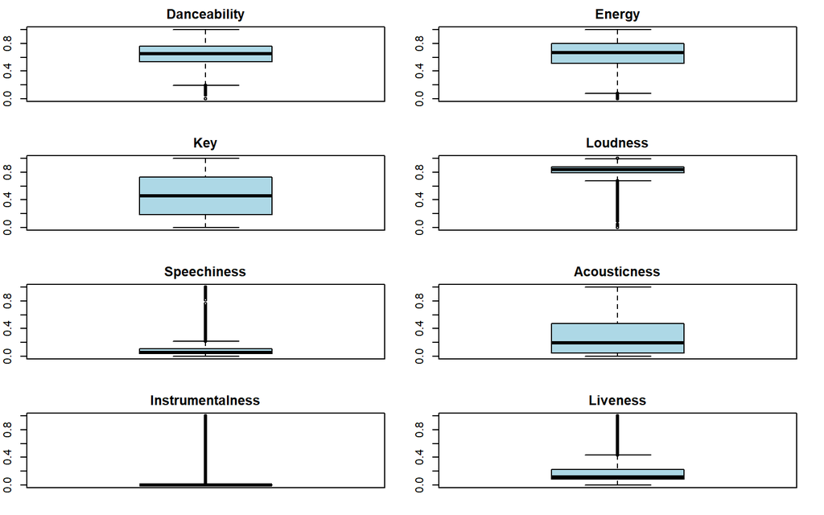

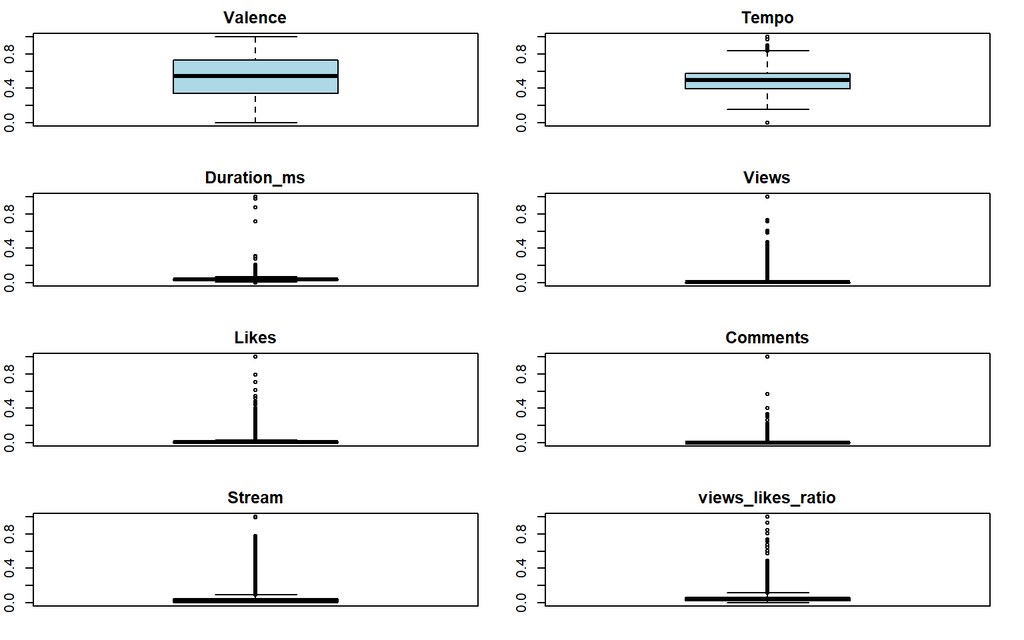

### 2.3 Análisis conjunto de variables (correlaciones)

A continuación, se presenta la Matriz de correlaciones entre las variables del conjunto de datos.

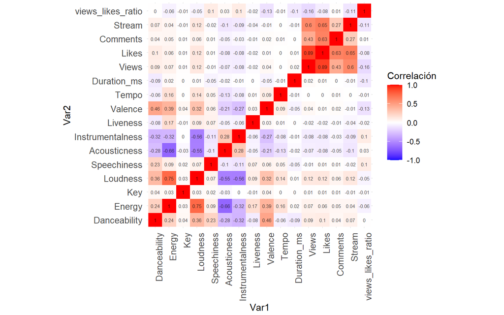

Basado en la Matriz de correlaciones, a continuación se describen algunas de las correlaciones más relevantes, que se identificaron:

**Danceability:** Tiene una correlación positiva moderada con Loudness (0.36), Valence (0.46) y Energy (0.24).

**Energy:** Muestra una correlación positiva fuerte con Loudness (0.75).

**Loudness:** Tiene una correlación positiva moderada con Danceability (0.36) y Energy (0.75).

**Valence:** Muestra una correlación positiva moderada con Danceability (0.46) y una correlación negativa moderada con Acousticness (-0.21).

**Acousticness:** Tiene una correlación negativa moderada con Energy (-0.66).

**Views:** Tiene una correlación positiva fuerte con Likes (0.89).

**Likes:** Muestra una correlación positiva fuerte con Views (0.89) y una correlación moderada con Comments (0.63).

**Comments**: Tiene una correlación moderada con Views (0.43) y Likes (0.63).

**Stream**: Muestra una correlación moderada con Views (0.60) y Likes (0.65).

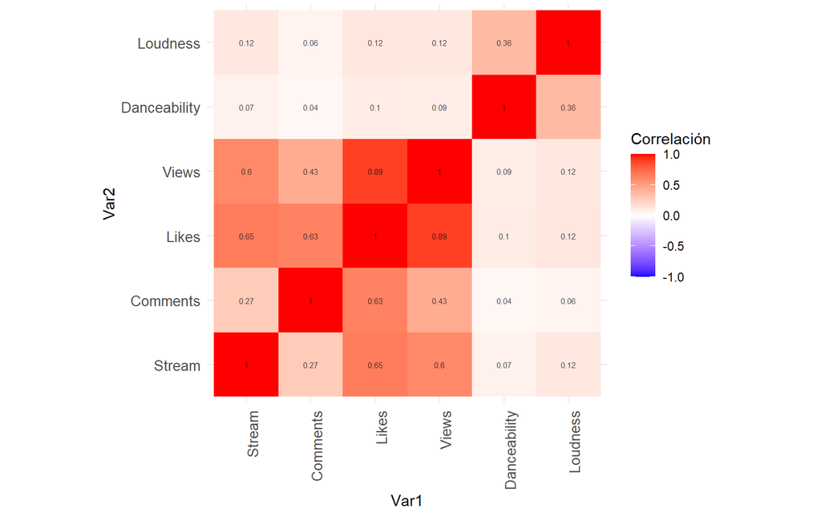

## 3. Presentación del análisis estadístico de los datos

### 3.1 Modelo de Regresión Lineal Múltiple.

A continuación se realiza el modelo de regresión lineal múltiple a las variables del conjunto de datos que presentaron correlación significativa:

Resumen del modelo de regresión lineal múltiple datos_RL

|  | Coefficients | Estimate | Std..Error | t.value | Pr…t.. | Multiple.R.squared | Adjusted.R.squared |
| --- | --- | --- | --- | --- | --- | --- | --- |
| (Intercept) | (Intercept) | -0.0023958 | 0.0007107 | -3.3710019 | 0.0007504 | 0.8915473 | 0.8915195 |
| Danceability | Danceability | 0.0029436 | 0.0005289 | 5.5658931 | 0.0000000 | 0.8915473 | 0.8915195 |
| Loudness | Loudness | 0.0008063 | 0.0009210 | 0.8753893 | 0.3813729 | 0.8915473 | 0.8915195 |
| Views | Views | 0.6746588 | 0.0032679 | 206.4528504 | 0.0000000 | 0.8915473 | 0.8915195 |
| Comments | Comments | 0.8788477 | 0.0076198 | 115.3381228 | 0.0000000 | 0.8915473 | 0.8915195 |
| Stream | Stream | 0.0879421 | 0.0014448 | 60.8686330 | 0.0000000 | 0.8915473 | 0.8915195 |

El modelo de regresión lineal tiene las siguientes conclusiones principales:

Las variables predictoras Danceability, Views, Comments y Stream tienen un impacto significativo en la variable de respuesta Likes. Esto se evidencia por los valores p muy bajos (< 0.05) asociados a estas variables en la tabla de coeficientes.

La variable Danceability muestra una relación positiva significativa con Likes, lo que indica que a medida que aumenta la danceabilidad de una canción, es probable que aumente el número de likes.

Las variables Views, Comments y Stream también tienen una relación positiva significativa con Likes. Esto sugiere que cuanto más vistas, comentarios y transmisiones tenga una canción, es más probable que tenga más likes.

La variable Loudness no muestra una relación significativa con Likes, como se indica por el valor p elevado (0.38137). Esto implica que el nivel de sonoridad no tiene un impacto significativo en el número de likes.

El modelo tiene un coeficiente de determinación (R-cuadrado) de 0.8915, lo que significa que aproximadamente el **89.15%** de la variabilidad en la variable Likes puede ser explicada por las variables predictoras incluidas en el modelo.

En resumen, el modelo sugiere que la danceabilidad, las vistas, los comentarios y las transmisiones son factores importantes que influyen en la cantidad de likes que recibe una canción, mientras que el nivel de sonoridad no tiene un impacto significativo en los Likes.

Con el objetivo de mejorar el ajuste del modelo de regresión lineal múltiple, consideraremos la eliminación de la variable Loudness que arrojó un valor p alto (p > 0.05n):

Al retirar esta variable, el modelo podría tener un mayor ajuste y mayor capacidad para explicar la variabilidad en la variable dependiente “Likes”.

Resumen del modelo de regresión lineal múltiple datos_RL1

|  | Coefficients | Estimate | Std..Error | t.value | Pr…t.. | Multiple.R.squared | Adjusted.R.squared |
| --- | --- | --- | --- | --- | --- | --- | --- |
| (Intercept) | (Intercept) | -0.0018432 | 0.0003265 | -5.645474 | 0 | 0.891543 | 0.8915208 |
| Danceability | Danceability | 0.0031058 | 0.0004953 | 6.269886 | 0 | 0.891543 | 0.8915208 |
| Views | Views | 0.6747635 | 0.0032657 | 206.624481 | 0 | 0.891543 | 0.8915208 |
| Comments | Comments | 0.8788936 | 0.0076195 | 115.347560 | 0 | 0.891543 | 0.8915208 |
| Stream | Stream | 0.0880121 | 0.0014426 | 61.010973 | 0 | 0.891543 | 0.8915208 |

En resumen, ambos modelos llegan a conclusiones similares en términos de las variables predictoras Danceability, Views, Comments y Stream, las cuales tienen un impacto significativo en la cantidad de likes. Sin embargo, la variable Loudness no muestra un efecto significativo en los likes, por lo que su inclusión en el modelo no es necesaria para explicar la variabilidad en la variable de respuesta.

### 3.2 Modelo PCA.

En esta etapa del análisis, se procederá a implementar el modelo PCA al conjunto de datos “datos”. El PCA, o Análisis de Componentes Principales, es una técnica utilizada para reducir la dimensionalidad de un conjunto de datos y extraer la información más relevante.

Relación de participación de las variables en los componentes

|  | PC1 | PC2 | PC3 | PC4 | PC5 | PC6 | PC7 | PC8 | PC9 | PC10 | PC11 | PC12 | PC13 | PC14 | PC15 | PC16 | var_exp |
| --- | --- | --- | --- | --- | --- | --- | --- | --- | --- | --- | --- | --- | --- | --- | --- | --- | --- |
| Danceability | 0.2799606 | 0.1539126 | 0.5097511 | -0.2480573 | 0.0717180 | 0.0009770 | -0.0657764 | 0.0624970 | 0.1175435 | -0.0359087 | -0.1738182 | -0.6260252 | 0.2136541 | -0.2246215 | 0.1721504 | -0.0145818 | 20.8633917 |
| Energy | 0.3867395 | 0.2716819 | -0.2278834 | 0.1414756 | -0.0295428 | -0.0198800 | -0.0679830 | -0.1653760 | 0.0689910 | -0.2522000 | 0.0351905 | 0.2982484 | 0.1151112 | -0.1922488 | 0.6801944 | 0.0026111 | 16.2351611 |
| Key | 0.0276038 | 0.0191370 | 0.0737596 | -0.0821679 | -0.5285550 | -0.8066561 | 0.0798717 | -0.1431456 | -0.1189356 | 0.1238393 | -0.0077880 | -0.0035660 | -0.0119570 | -0.0023251 | 0.0064253 | -0.0004914 | 7.9644558 |
| Loudness | 0.4179956 | 0.2405056 | -0.1317968 | 0.0509488 | -0.0255146 | 0.0632203 | -0.1220234 | -0.1196550 | -0.1218029 | 0.1660338 | 0.0601706 | 0.1584446 | 0.2763873 | -0.4512495 | -0.6019697 | -0.0101832 | 7.1753512 |
| Speechiness | 0.0894866 | 0.0910333 | 0.4133927 | 0.3425965 | 0.1866082 | -0.2312357 | -0.0174585 | 0.6149271 | -0.2504042 | -0.2636062 | 0.1791664 | 0.2437905 | -0.0357362 | -0.0162664 | -0.0579111 | -0.0092836 | 6.2800879 |
| Acousticness | -0.3484034 | -0.2150388 | 0.1650939 | -0.1622501 | 0.1226381 | -0.0276339 | 0.2265534 | 0.1413425 | 0.1185772 | 0.3891708 | -0.0833388 | 0.3569844 | 0.2690453 | -0.5195520 | 0.2222721 | -0.0078824 | 6.2660113 |
| Instrumentalness | -0.3081307 | -0.1765405 | -0.0314756 | 0.1292779 | -0.1280634 | -0.0799123 | 0.0077761 | -0.1229266 | 0.2848532 | -0.7295579 | -0.1724239 | -0.0336583 | 0.1733746 | -0.3083712 | -0.2209452 | -0.0007629 | 6.0728596 |
| Liveness | 0.0465753 | 0.0789807 | -0.2755659 | 0.3517757 | 0.6020618 | -0.4024295 | 0.3475219 | -0.0899936 | 0.1527891 | 0.1239857 | -0.1996995 | -0.2397932 | -0.0094949 | -0.0017052 | -0.0491986 | -0.0008746 | 5.8601711 |
| Valence | 0.2612216 | 0.2079440 | 0.2186244 | -0.3268616 | 0.0178654 | -0.0062570 | 0.2922205 | 0.0280544 | 0.5141329 | -0.0795066 | -0.2536100 | 0.4036704 | -0.2601935 | 0.2064952 | -0.1969065 | 0.0177318 | 5.1247084 |
| Tempo | 0.0875957 | 0.0806888 | -0.2304182 | 0.2994411 | -0.5097463 | 0.2559853 | 0.4693629 | 0.4494933 | 0.1107633 | 0.1071043 | -0.1427907 | -0.2130168 | 0.0572177 | -0.0422927 | 0.0276703 | -0.0031475 | 4.7361413 |
| Duration_ms | -0.0021643 | -0.0168564 | -0.4220154 | -0.2220184 | 0.0333371 | -0.2135952 | -0.5709135 | 0.5208557 | 0.2731426 | 0.0735830 | -0.2137585 | -0.0361336 | -0.0220824 | -0.0290947 | -0.0004729 | 0.0008446 | 4.2915550 |
| Views | 0.2935843 | -0.4517097 | -0.0147887 | -0.0293716 | 0.0288333 | -0.0233483 | 0.0494061 | 0.0241015 | -0.0488297 | -0.0416521 | -0.1456627 | 0.1070850 | 0.4785321 | 0.3387736 | -0.0069386 | -0.5689237 | 2.9989570 |
| Likes | 0.3086232 | -0.4853655 | 0.0318198 | 0.0663180 | 0.0034261 | -0.0181674 | -0.0042656 | 0.0056866 | 0.0558958 | 0.0144010 | -0.0156608 | 0.0364812 | 0.1903202 | 0.1225429 | -0.0002501 | 0.7792450 | 2.4842851 |
| Comments | 0.2040089 | -0.3427545 | 0.0632000 | 0.1745894 | -0.0446075 | -0.0406349 | -0.0589804 | -0.0256439 | 0.4928356 | 0.1133097 | 0.5923106 | -0.1156679 | -0.2946882 | -0.1977763 | -0.0025335 | -0.2296667 | 2.2300332 |
| Stream | 0.2517316 | -0.3778886 | -0.0218867 | -0.0212771 | 0.0079982 | 0.0571151 | 0.0210388 | -0.0201718 | -0.3528075 | -0.0605900 | -0.4345447 | 0.0042768 | -0.5805588 | -0.3455869 | 0.0390649 | -0.1171639 | 1.0042140 |
| views_likes_ratio | -0.0878801 | 0.0491955 | 0.3250301 | 0.5856262 | -0.1450942 | 0.0732451 | -0.3991270 | -0.1918707 | 0.2170638 | 0.2863101 | -0.4058178 | 0.1126527 | -0.0138000 | 0.1002688 | 0.0132821 | -0.0427884 | 0.4126164 |

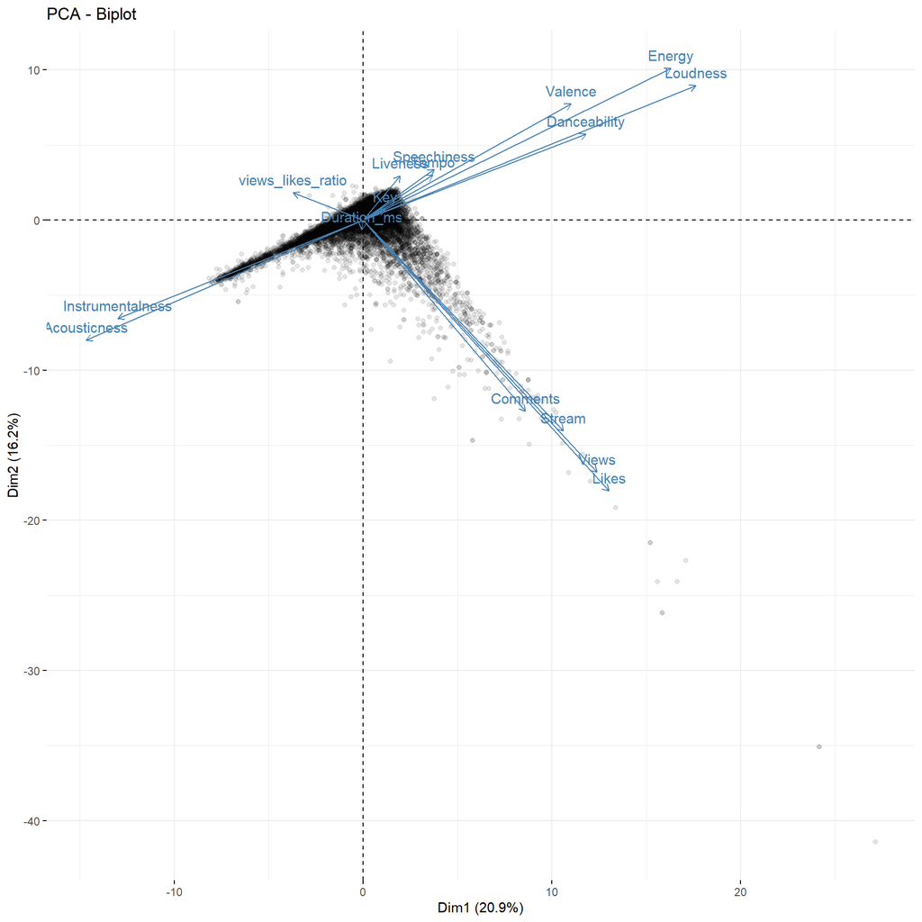

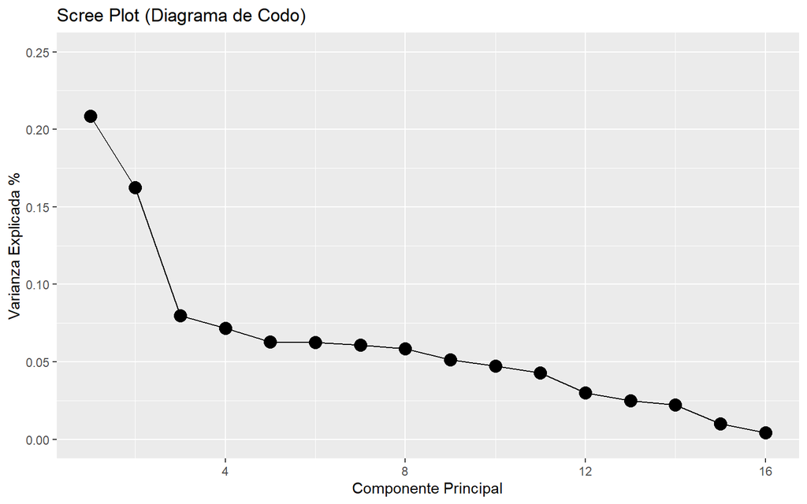

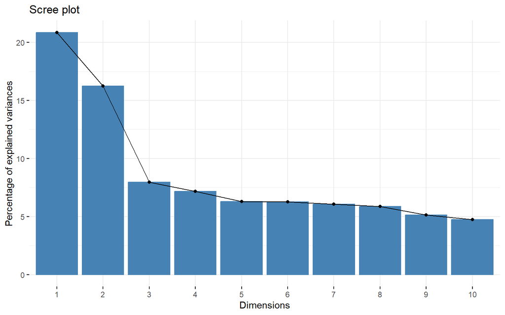

## 3.3 Análisis de Cluster.

El análisis de clúster (cluster) que se realizará en este capítulo, tiene como objetivo agrupar las observaciones en conjuntos homogéneos o clústeres, según la similitud de sus características. En este caso, se aplicó el análisis de clúster jerárquico utilizando diferentes métodos de enlace, como enlace completo, enlace simple, enlace promedio y enlace Ward.

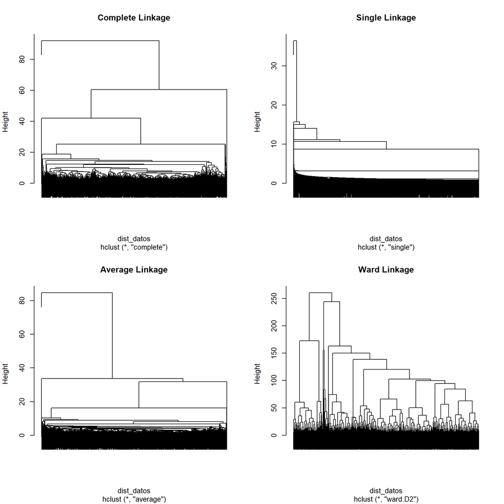

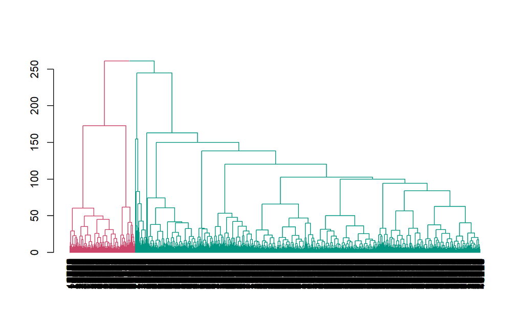